# ST 558 Project 2

Kaylee Frazier and Rebecca Voelker

10/31/2021

## Introduction

#### The following is an analysis of online news popularity across a variety of channels. This analysis covers the following 6 data channels:

1. Lifestyle
2. Entertainment
3. Business
4. Social Media
5. Tech
6. World

#### The following report analyzes the # of shares of a particular piece of content as a function of a variety of variables, including;

- Number of Images in the Content (num_imgs)
- Number of Videos in the Content (num_videos)
- Week vs. Weekend Publications (is_weekend)
- Number of Words in the Content (n_tokens_content)
- Number of Words in the Title (n_tokens_titel)
- Polarity of the Content Title (abs_title_sentiment_polarity)

#### A few new variables were created, as well, which are described alongside the respective R Code.

#### As a part of our analysis, we modeled each of our predictive variables linearly, as well as via Random Forest and Boosted Tree Models. The various models were then compared against one another to select our final model, which was fit to our test data.

```r
#Read in Libraries

library(tidyverse)
library(readr)
library(ggplot2)
library(randomForest)
library(shiny)
library(dplyr)
library(caret)
```

```r
## Check Working Directory Path
getwd()
```

```
## [1] "C:/Users/Rebecca/OneDrive/Desktop/ST 558/Repos/Project2"
```

```r
## Read in Raw Data Using Relative Path
rawData <- read_csv(file = "./project2_rawdata.csv")
rawData
```

```
## # A tibble: 39,644 x 61
##    url        timedelta n_tokens_title n_tokens_content n_unique_tokens
##    <chr>          <dbl>          <dbl>            <dbl>           <dbl>
##  1 http://ma~       731             12              219           0.664
##  2 http://ma~       731              9              255           0.605
##  3 http://ma~       731              9              211           0.575
##  4 http://ma~       731              9              531           0.504
##  5 http://ma~       731             13             1072           0.416
##  6 http://ma~       731             10              370           0.560
##  7 http://ma~       731              8              960           0.418
##  8 http://ma~       731             12              989           0.434
##  9 http://ma~       731             11               97           0.670
## 10 http://ma~       731             10              231           0.636
## # ... with 39,634 more rows, and 56 more variables:
## #   n_non_stop_words <dbl>, n_non_stop_unique_tokens <dbl>,
## #   num_hrefs <dbl>, num_self_hrefs <dbl>, num_imgs <dbl>,
## #   num_videos <dbl>, average_token_length <dbl>, num_keywords <dbl>,
## #   data_channel_is_lifestyle <dbl>,
## #   data_channel_is_entertainment <dbl>, data_channel_is_bus <dbl>,
## #   data_channel_is_socmed <dbl>, data_channel_is_tech <dbl>, ...
```

```r
## Create a New Variable to Data Channel
rawDataNew <- rawData %>% mutate(data_channel =   if_else(data_channel_is_bus == 1, "Business",
       if_else(data_channel_is_entertainment == 1, "Entertainment",
               if_else(data_channel_is_lifestyle == 1, "Lifestyle",
                      if_else(data_channel_is_socmed == 1, "Social Media",
                              if_else(data_channel_is_tech == 1, "Tech", "World"))))))

## Subset Data for Respective Data Channel
subsetData <- rawDataNew %>% filter(data_channel == params$data_channel)

## Create Training and Test Data Sets
set.seed(500)
trainIndex <- createDataPartition(subsetData$shares, p = 0.7, list = FALSE)

trainData <- subsetData[trainIndex,]
testData <- subsetData[-trainIndex,]

trainData
```

```
## # A tibble: 4,382 x 62
##    url        timedelta n_tokens_title n_tokens_content n_unique_tokens
##    <chr>          <dbl>          <dbl>            <dbl>           <dbl>
##  1 http://ma~       731              9              211           0.575
##  2 http://ma~       731             13              244           0.560
##  3 http://ma~       731              8              708           0.482
##  4 http://ma~       731             10              142           0.655
##  5 http://ma~       730             13              306           0.535
##  6 http://ma~       729             10              468           0.534
##  7 http://ma~       729              6              164           0.588
##  8 http://ma~       729             11              173           0.724
##  9 http://ma~       729              9              330           0.502
## 10 http://ma~       729             10              381           0.546
## # ... with 4,372 more rows, and 57 more variables:
## #   n_non_stop_words <dbl>, n_non_stop_unique_tokens <dbl>,
## #   num_hrefs <dbl>, num_self_hrefs <dbl>, num_imgs <dbl>,
## #   num_videos <dbl>, average_token_length <dbl>, num_keywords <dbl>,
## #   data_channel_is_lifestyle <dbl>,
## #   data_channel_is_entertainment <dbl>, data_channel_is_bus <dbl>,
## #   data_channel_is_socmed <dbl>, data_channel_is_tech <dbl>, ...
```

```r
testData
```

```
## # A tibble: 1,876 x 62
##    url        timedelta n_tokens_title n_tokens_content n_unique_tokens
##    <chr>          <dbl>          <dbl>            <dbl>           <dbl>
##  1 http://ma~       731              9              255           0.605
##  2 http://ma~       731              8              397           0.625
##  3 http://ma~       731             11              723           0.491
##  4 http://ma~       731             12              444           0.601
##  5 http://ma~       731              6              109           0.667
##  6 http://ma~       729              9              759           0.499
##  7 http://ma~       729              9              233           0.553
##  8 http://ma~       729             10              424           0.553
##  9 http://ma~       728             10              347           0.517
## 10 http://ma~       728             16              487           0.520
## # ... with 1,866 more rows, and 57 more variables:
## #   n_non_stop_words <dbl>, n_non_stop_unique_tokens <dbl>,
## #   num_hrefs <dbl>, num_self_hrefs <dbl>, num_imgs <dbl>,
## #   num_videos <dbl>, average_token_length <dbl>, num_keywords <dbl>,
## #   data_channel_is_lifestyle <dbl>,
## #   data_channel_is_entertainment <dbl>, data_channel_is_bus <dbl>,
## #   data_channel_is_socmed <dbl>, data_channel_is_tech <dbl>, ...
```

## Exploratory Data Analysis (EDA)

### Create New Variables for EDA

```r
#Create New Variable that Measures Title Length
trainData <- trainData %>% mutate(TitleLength = if_else(n_tokens_title <= 10, "Short Title",
  if_else(n_tokens_title <= 15, "Medium Title", "Long Title")))

#Create New variable using weekday_is_() variables
trainDataNew <- trainData %>% mutate(day_of_the_week =   if_else(weekday_is_monday == 1, "Monday",
       if_else(weekday_is_tuesday == 1, "Tuesday",
               if_else(weekday_is_wednesday == 1, "Wednesday",
                      if_else(weekday_is_thursday == 1, "Thursday",
                              if_else(weekday_is_friday == 1, "Friday",
                                      if_else(weekday_is_saturday == 1, "Saturday", "Sunday"
                                              )))))))
trainDataNew
```

```
## # A tibble: 4,382 x 64
##    url        timedelta n_tokens_title n_tokens_content n_unique_tokens
##    <chr>          <dbl>          <dbl>            <dbl>           <dbl>
##  1 http://ma~       731              9              211           0.575
##  2 http://ma~       731             13              244           0.560
##  3 http://ma~       731              8              708           0.482
##  4 http://ma~       731             10              142           0.655
##  5 http://ma~       730             13              306           0.535
##  6 http://ma~       729             10              468           0.534
##  7 http://ma~       729              6              164           0.588
##  8 http://ma~       729             11              173           0.724
##  9 http://ma~       729              9              330           0.502
## 10 http://ma~       729             10              381           0.546
## # ... with 4,372 more rows, and 59 more variables:
## #   n_non_stop_words <dbl>, n_non_stop_unique_tokens <dbl>,
## #   num_hrefs <dbl>, num_self_hrefs <dbl>, num_imgs <dbl>,
## #   num_videos <dbl>, average_token_length <dbl>, num_keywords <dbl>,
## #   data_channel_is_lifestyle <dbl>,
## #   data_channel_is_entertainment <dbl>, data_channel_is_bus <dbl>,
## #   data_channel_is_socmed <dbl>, data_channel_is_tech <dbl>, ...
```

### Graphical summary of shares by Content Length and Weekday vs. Weekend

```r
#Convert is_weekend to a Factor
trainData$is_weekend <- factor(trainData$is_weekend)

#Table of Publications on Weekdays vs. Weekend
table(trainData$is_weekend)
```

```
##
##    0    1
## 3978  404
```

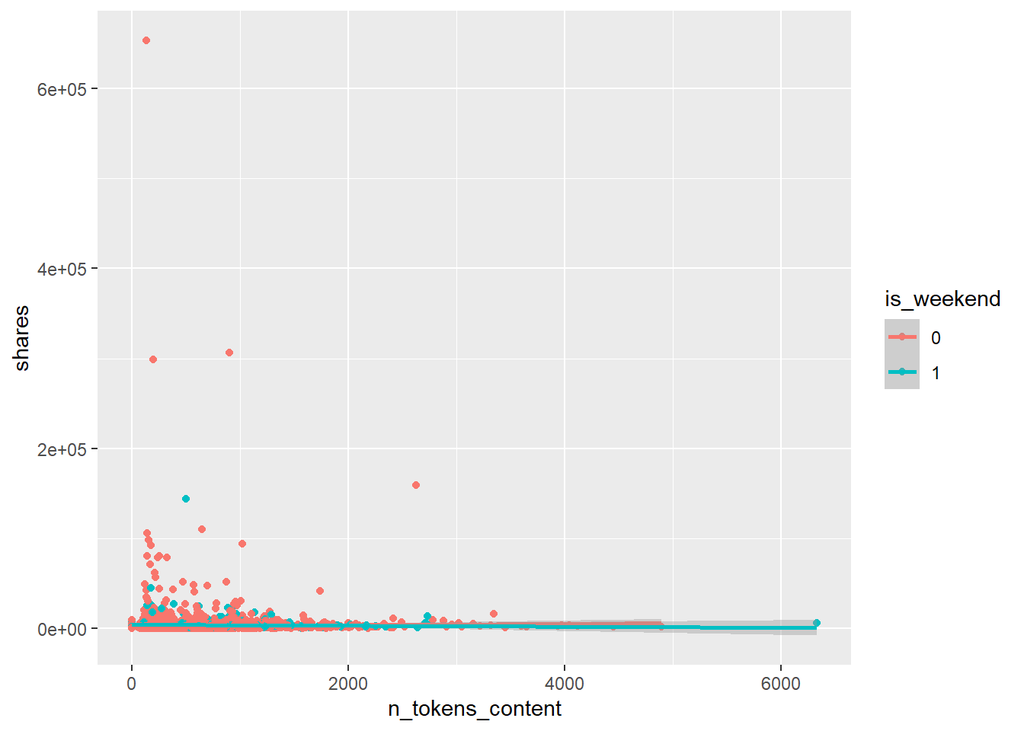

```r
#Create a Scatter Plot of # of Words by Shares
g1 <- ggplot(trainData, aes(x = n_tokens_content, y = shares)) +
  geom_point(aes(col = is_weekend)) +
    geom_smooth(method = "lm", aes(col = is_weekend))
g1
```

#### We can inspect the trend of shares as a function of the number of words (tokens) in the content. If the points show an upward trend, then content with more words tends to be shared more often.If we see a negative trend then content with more words tends to be shared less often. The color-coding specifies if the content was published on a Weekday or Weekend.

### Graphical and Numerical summary of shares by Weekday vs. Weekend

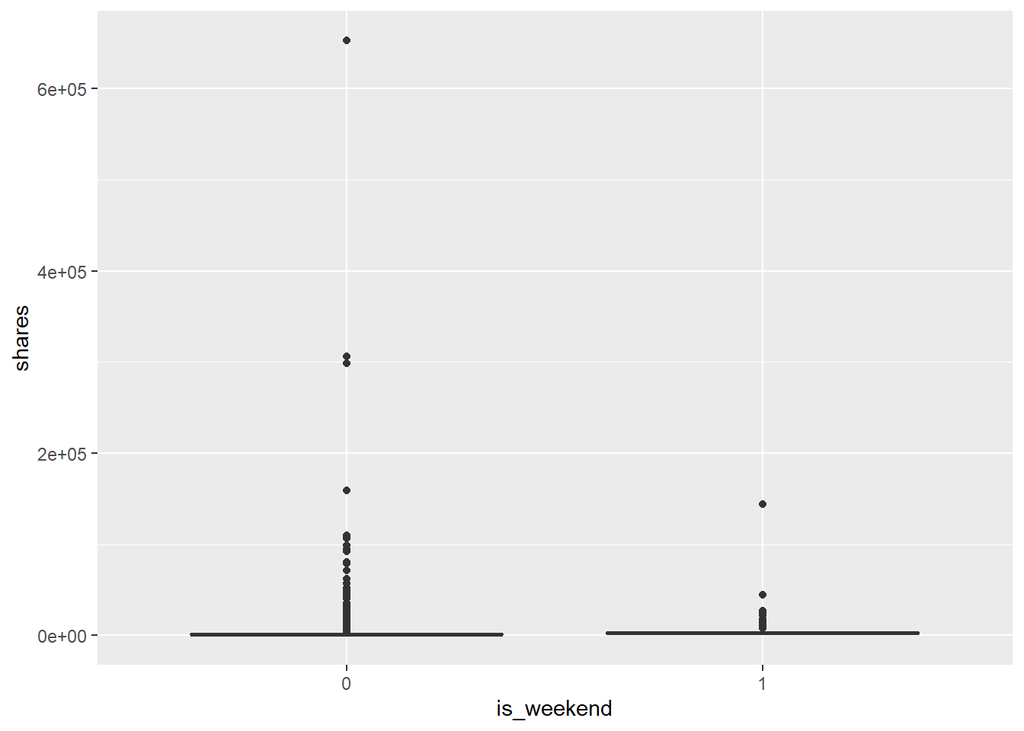

```r
#Create a Box Plot of Weekend vs. Weekday by Shares
g2 <- ggplot(trainData, aes(x = is_weekend, y = shares)) +
  geom_boxplot()
g2
```

```r
#Generate a Numerical Summary of Data Summarized in our Box Plot
trainData %>% group_by(is_weekend) %>% summarise(min = min(shares), med = median(shares), max = max(shares), mean = mean(shares))
```

```
## # A tibble: 2 x 5
##   is_weekend   min   med    max  mean
##   <fct>      <dbl> <dbl>  <dbl> <dbl>
## 1 0              1  1300 652900 2929.
## 2 1            150  2500 144400 4037.
```

#### We can inspect the trend of shares as a function of Weekday vs. Weekend Publications. The statistics show the Minimum, Maximum, Median, and Average # of Shares by Week (Published During the Week) vs. Weekend (Published During the Weekend)

### Graphical and Numerical summary of shares by Title Polarity and Length

```r
table(trainData$n_tokens_title)
```

```
##
##   3   4   5   6   7   8   9  10  11  12  13  14  15  16  17  18  19
##   3   5  33 101 260 533 688 784 757 567 346 187  84  25   6   2   1
```

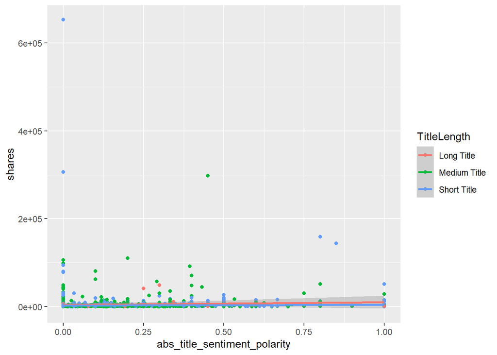

```r
# Create a Scatter Plot of Polarity of Title by Shares
g3 <- ggplot(trainData, aes(x = abs_title_sentiment_polarity, y = shares)) +
  geom_point(aes(col = TitleLength)) +
    geom_smooth(method = "lm", aes(col = TitleLength))
g3
```

```r
# Numerical Correlation of Polarity of Title by Shares
cor(trainData$abs_title_sentiment_polarity, trainData$shares)
```

```
## [1] 0.02683986
```

#### We can inspect the trend of shares as a function of the polarity of the title of the content. If the points show an upward trend, then content with a more polarizing title (positive or negative) tends to be shared more often.If we see a negative trend then content with more a more polarizing title (positive or negative) tends to be shared less often. The color-coding specifies the length of the title. The correlation, shows us the numerical value of the correlation between our predictor variable(s) and response

### Numerical summary of shares by day_of_the_week

```r
#find mean, median, and standard deviation of shares by day_of_the_week
daySummary <-trainDataNew %>% group_by(day_of_the_week) %>% summarise(avg_shares = mean(shares), med_shares = median(shares), sd_shares = sd(shares))

#print out numerical summary
daySummary
```

```
## # A tibble: 7 x 4
##   day_of_the_week avg_shares med_shares sd_shares
##   <chr>                <dbl>      <dbl>     <dbl>
## 1 Friday               2290.       1400     4361.
## 2 Monday               3649.       1400    23601.
## 3 Saturday             4904.       2700    11955.
## 4 Sunday               3462.       2200     4340.
## 5 Thursday             3174.       1300    15414.
## 6 Tuesday              2782.       1300     6923.
## 7 Wednesday            2593.       1300     8011.
```

#### In the summary plot you can see which days had the highest and lowest average shares, median shares, and look at the standard deviation to see which day had the largest range of shares.

### Bar chart of shares by day of the week

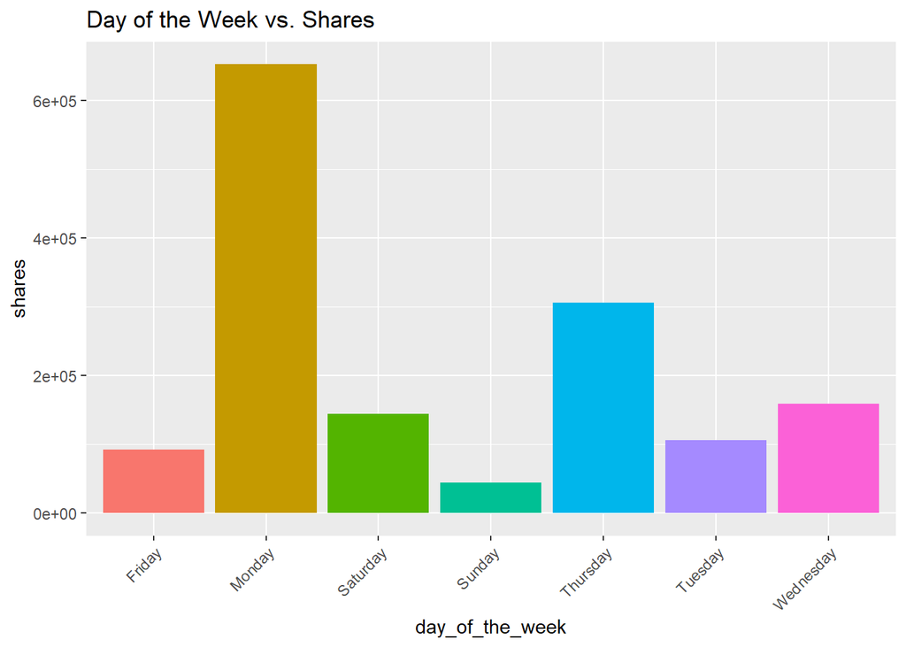

```r
#create a basic plot with x and y variables
g5 <- ggplot(data = trainDataNew, aes(day_of_the_week, shares))
#make the plot a bar chart
g5 + geom_col(aes(fill = day_of_the_week), position = "dodge") +
#change the angle of the words to fit
  guides(x = guide_axis(angle = 45)) +
  labs(title = "Day of the Week vs. Shares") +
#get rid of legend
  theme(legend.position = "none")
```

### Summary table of shares by number of images

```r
#create summary table with different ranges of images
imagesSummary <- trainData %>% group_by(cut(num_imgs, c(min(num_imgs), 10, 20, 40, 60, 80, max(num_imgs)))) %>% summarise(avg_shares = mean(shares), med_shares = median(shares), sd_shares = sd(shares))

#rename column name
names(imagesSummary)[names(imagesSummary) == "cut(num_imgs, c(min(num_imgs), 10, 20, 40, 60, 80, max(num_imgs)))"] <- "image_number"

#print out numerical summary
imagesSummary
```

```
## # A tibble: 5 x 4
##   image_number avg_shares med_shares sd_shares
##   <fct>             <dbl>      <dbl>     <dbl>
## 1 (0,10]            2431.       1400     5066.
## 2 (10,20]           6060.       2150    26533.
## 3 (20,40]          13860.       1500    58454.
## 4 (40,51]           1500        1500       NA
## 5 <NA>              5970.       1400    31139.
```

#### In the summary plot you can see if the amount of images affected the average, median, and standard deviation of shares.

### Scatter plot of the image number and shares.

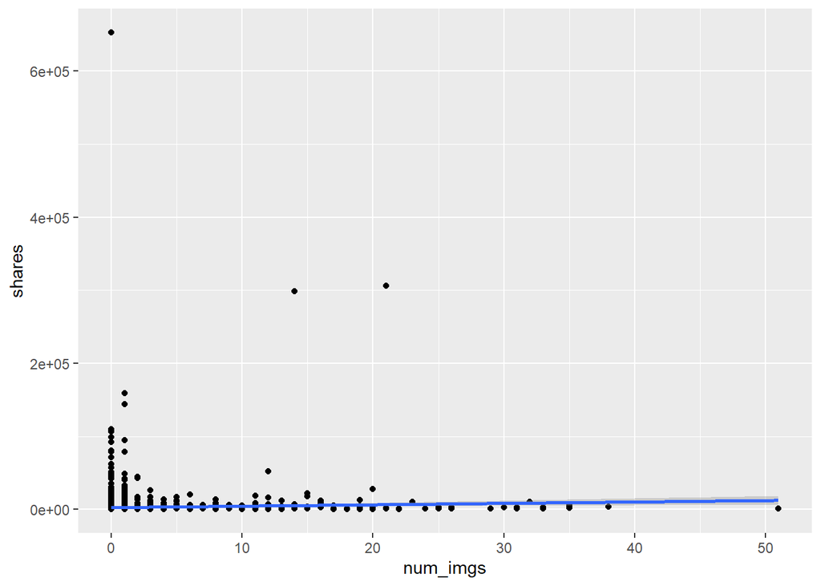

```r
#create basic plot with x and y
g6 <- ggplot(trainData, aes(x = num_imgs, y = shares))
#make it a scatter plot with regression line
g6 + geom_point() +
    geom_smooth(method = "lm")
```

#### In this scatter plot of the number of images vs. shares, you can see the relationship between the two variables. If it shows an upward trend, articles with more images tend to be shared more often. If the trend is negative, then articles with less images tend to be shared more.

### Scatter plot of the number of videos and shares.

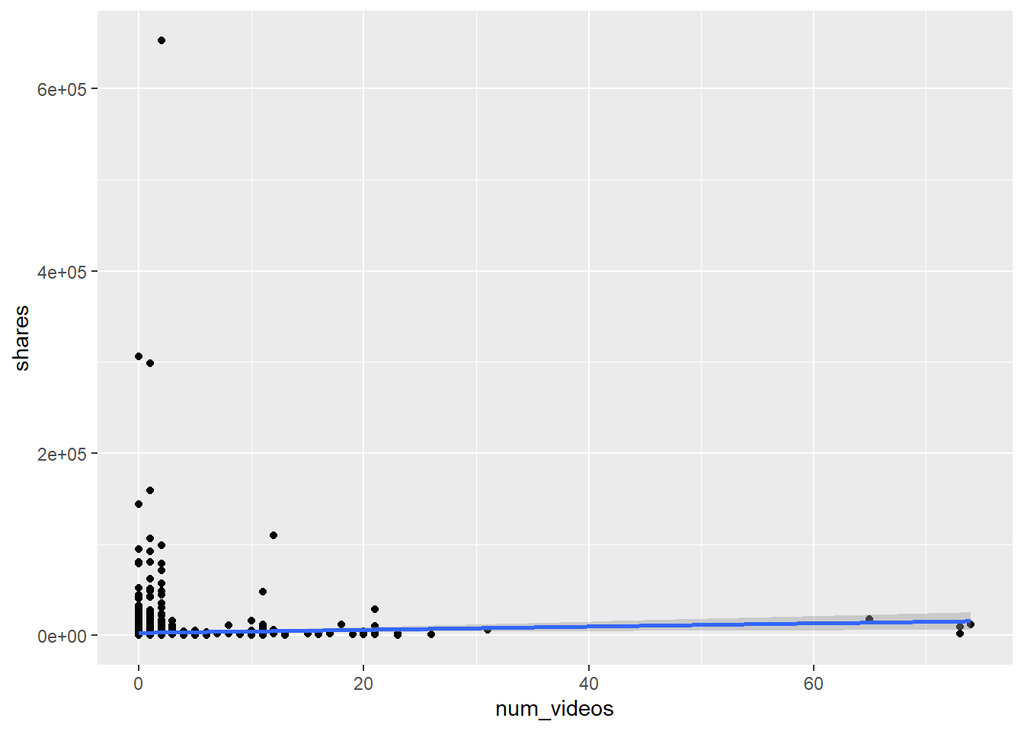

```r
#create basic plot with x and y
g7 <- ggplot(trainData, aes(x = num_videos, y = shares))
#make it a scatter plot with regression line
g7 + geom_point() +
    geom_smooth(method = "lm")
```

#### In this scatter plot of the number of videos vs. shares, you can see the relationship between the two variables. If it shows an upward trend, articles with more videos tend to be shared more often. If the trend is negative, then articles with less videos tend to be shared more.

## Modeling

### Linear Regression Models

#### A linear regression model allows for easy prediction of a response variable. It’s goal is to figure out which variables are significant predictors of the response variable and how do they impact it.

#### This Multiple Linear Regression Model looks at the # of Shares as a function of the # of Words in the Content AND whether or not the Content was published on a Weekend (0 = No, 1 = Yes)

```r
## Convert is_weekend to Numeric
trainData$is_weekend <- as.numeric(trainData$is_weekend)

## Fit Multiple Linear Regression Model
fitLM1 <- train(shares ~ n_tokens_content + is_weekend, data = trainData, method = "lm", trControl = trainControl(method = "cv", number = 10))
fitLM1
```

```
## Linear Regression
##
## 4382 samples
##    2 predictor
##
## No pre-processing
## Resampling: Cross-Validated (10 fold)
## Summary of sample sizes: 3944, 3944, 3943, 3944, 3944, 3944, ...
## Resampling results:
##
##   RMSE      Rsquared     MAE
##   10510.39  0.004757362  2669.599
##
## Tuning parameter 'intercept' was held constant at a value of TRUE
```

```r
## Fit Multiple Linear Regression Model
fitLM2 <- train(shares ~ abs_title_sentiment_polarity^2 + TitleLength, data = trainData, method = "lm", trControl = trainControl(method = "cv", number = 10))
fitLM2
```

```
## Linear Regression
##
## 4382 samples
##    2 predictor
##
## No pre-processing
## Resampling: Cross-Validated (10 fold)
## Summary of sample sizes: 3944, 3944, 3944, 3944, 3944, 3942, ...
## Resampling results:
##
##   RMSE      Rsquared     MAE
##   10124.68  0.003578414  2712.194
##
## Tuning parameter 'intercept' was held constant at a value of TRUE
```

#### This multiple linear regression model looks at day of the week, number of images, and number of videos as predictors and shares as response.

```r
#create fit using shares as response, day_of_the_week, num_imgs, and num_videos as the predictors
fitLM3 <- train(shares ~ day_of_the_week + num_imgs + num_videos, data = trainDataNew,
#method is linear model
              method = "lm",
#center and scale the data
                preProcess = c("center", "scale"),
#10 fold cross validation
              trControl = trainControl(method = "cv", number = 10))
fitLM3
```

```
## Linear Regression
##
## 4382 samples
##    3 predictor
##
## Pre-processing: centered (8), scaled (8)
## Resampling: Cross-Validated (10 fold)
## Summary of sample sizes: 3944, 3945, 3944, 3943, 3943, 3944, ...
## Resampling results:
##
##   RMSE      Rsquared    MAE
##   10488.95  0.01067003  2684.151
##
## Tuning parameter 'intercept' was held constant at a value of TRUE
```

### Random Forest Model

#### Random forest modeling is a type of ensemble model that creates multiple trees from bootstrap samples without using all the predictors and a random subset of predictors for each sample. It then averages the results from the multiple trees.

```r
#use train function
rfFit <- train(shares ~ day_of_the_week + num_imgs + num_videos + n_tokens_content, data = trainDataNew,
#use rf method
               method = "rf",
#5 fold validation
               trControl = trainControl(method = "cv", number = 5),
#consider values of mtry
               tuneGrid = data.frame(mtry = 1:4))
rfFit
```

```
## Random Forest
##
## 4382 samples
##    4 predictor
##
## No pre-processing
## Resampling: Cross-Validated (5 fold)
## Summary of sample sizes: 3506, 3505, 3506, 3506, 3505
## Resampling results across tuning parameters:
##
##   mtry  RMSE      Rsquared     MAE
##   1     11891.42  0.010465408  2666.313
##   2     12144.40  0.007896754  2684.302
##   3     12429.05  0.007549101  2717.067
##   4     12775.22  0.006929914  2779.598
##
## RMSE was used to select the optimal model using the smallest value.
## The final value used for the model was mtry = 1.
```

#### Boosted modeling is a type of ensemble model that grows subsequent trees off of modified version of the original data. Any resulting predictions are updated as your Boosted Tree Model grows, based on criteria like the # of Subsequent Trees, Shrinkage Paramter, etc.

```r
n.trees <- c(5, 10, 25, 100)
interaction.depth <- 1:4
shrinkage <- 0.1
n.minobsinnode <- 10

df <- expand.grid(n.trees = n.trees, interaction.depth = interaction.depth, shrinkage = shrinkage, n.minobsinnode = n.minobsinnode)

boostFit <- train(shares ~ abs_title_sentiment_polarity^2 + TitleLength, data = trainData, method = "gbm", trControl = trainControl(method = "cv", number = 5), tuneGrid = df)

boostFit$results
boostFit$bestTune
```

[output not shown]

## Model Comparison and Selection

```r
#Add New Variables (Title Length and Day of the Week) to Test Data
testData <- testData %>% mutate(TitleLength = if_else(n_tokens_title <= 10, "Short Title",
  if_else(n_tokens_title <= 15, "Medium Title", "Long Title")))

testData <- testData %>% mutate(day_of_the_week =   if_else(weekday_is_monday == 1, "Monday",
       if_else(weekday_is_tuesday == 1, "Tuesday",
               if_else(weekday_is_wednesday == 1, "Wednesday",
                      if_else(weekday_is_thursday == 1, "Thursday",
                              if_else(weekday_is_friday == 1, "Friday",
                                      if_else(weekday_is_saturday == 1, "Saturday", "Sunday"
                                              )))))))

## Obtain RMSE on Test Data for Linear Models
predLM1 <- predict(fitLM1, newdata = testData)
postResample(predLM1, obs = testData$shares)
```

```
##         RMSE     Rsquared          MAE
## 1.829744e+04 8.807110e-04 2.289314e+03
```

```r
predLM2 <- predict(fitLM2, newdata = testData)
postResample(predLM2, obs = testData$shares)
```

```
##         RMSE     Rsquared          MAE
## 1.828140e+04 2.050436e-05 2.810490e+03
```

```r
predLM3 <- predict(fitLM3, newdata = testData)
postResample(predLM3, obs = testData$shares)
```

```
##         RMSE     Rsquared          MAE
## 1.825641e+04 2.362166e-03 2.842232e+03
```

```r
## Obtain RMSE on Test Data for Random Forest Model
predRF <- predict(rfFit, newdata = testData)
postResample(predRF, testData$shares)
```

```
##         RMSE     Rsquared          MAE
## 1.817504e+04 1.821514e-02 2.791584e+03
```

```r
## Obtain RMSE on Test Data for Boosted Fit Model
predBoost <- predict(boostFit, newdata = testData)
postResample(predBoost, testData$shares)
```

```
##         RMSE     Rsquared          MAE
## 1.827863e+04 1.493896e-06 2.818807e+03
```

#### The model with the lowest RMSE should be used to predict shares as a function of the listed predictor variables, for that particular data channel.